# Problem Set 4

# Data visualization with nflfastR

We will now apply our newly acquired plotting skills to make some visualizations working with data from nflfastR. If you have not installed `nflfastR` yet, run `install.packages("nflfastR")` once in the console. Then load in our usual libraries, as well as nflfastR.

```r
library(tidyverse)
library(nflfastR)
library(ggplot2)
```

1. Let’s load in the data for the 2024 season. This dataset contains play-by-play data for all games in the 2024 NFL season.

```r
pbp_2024 <- load_pbp(2024)
```

2. We can see that there are more than 100 columns. Let’s tackle specific questions one at a time. First, look at quarterback completions by filtering for where `play_type == "pass"` and then selecting the following columns in a new table called `pbp_pass`.

```r
pbp_pass <- pbp_2024 %>%
  filter(play_type == "pass") %>%
  select(play_type, pass_location, yards_gained, air_yards, yards_after_catch,
         passer_player_name, complete_pass, incomplete_pass, cpoe)

head(pbp_pass)
```

```
## ── nflverse play by play data ──────────────────────────────────────────────────
```

```
## ℹ Data updated: 2025-09-03 05:24:26 EDT
```

```
## # A tibble: 6 × 9
##   play_type pass_location yards_gained air_yards yards_after_catch
##   <chr>     <chr>                <dbl>     <dbl>             <dbl>
## 1 pass      left                    22        -3                25
## 2 pass      middle                   9         2                 7
## 3 pass      middle                   8         6                 2
## 4 pass      right                    0        12                NA
## 5 pass      <NA>                     0        NA                NA
## 6 pass      left                     5         5                 0
## # ℹ 4 more variables: passer_player_name <chr>, complete_pass <dbl>,
## #   incomplete_pass <dbl>, cpoe <dbl>
```

3. nflfastR unfortunately does not include a position field to identify quarterbacks. To work around this, group by player and keep players with more than 150 pass attempts to remove players without sufficient play time. Hint: pass attempts will be the sum of entries in `complete_pass` and `incomplete_pass`.
4. Let’s take a preliminary look at how location might affect pass outcomes. First, use `!is.na()` with `filter()` to filter out pass attempts without a location label. Then create a bar plot to visualize the frequency of attempts in each pass location.
5. Let’s look at the distribution of yards gained based on pass location with some box plots. Use `geom_boxplot()` to create a box plot of `yards_gained` by `pass_location`.
6. Completion percentage over expected is a metric that adjusts for the difficulty of a QB’s throw based on throw timing, coverage, and location. Take a look at how `cpoe` differs based on pass location alone with `geom_violin()`.
7. Let’s now turn to aggregated pass statistics per quarterback. Group by `passer_player_name` and create a table called `pbp_grouped` with columns `passer_player_name`, `attempts`, `avg_yards_gained`, and `avg_cpoe` using `reframe()`.
8. First visualize how `attempts` and `avg_yards_gained` are related by using a scatterplot.

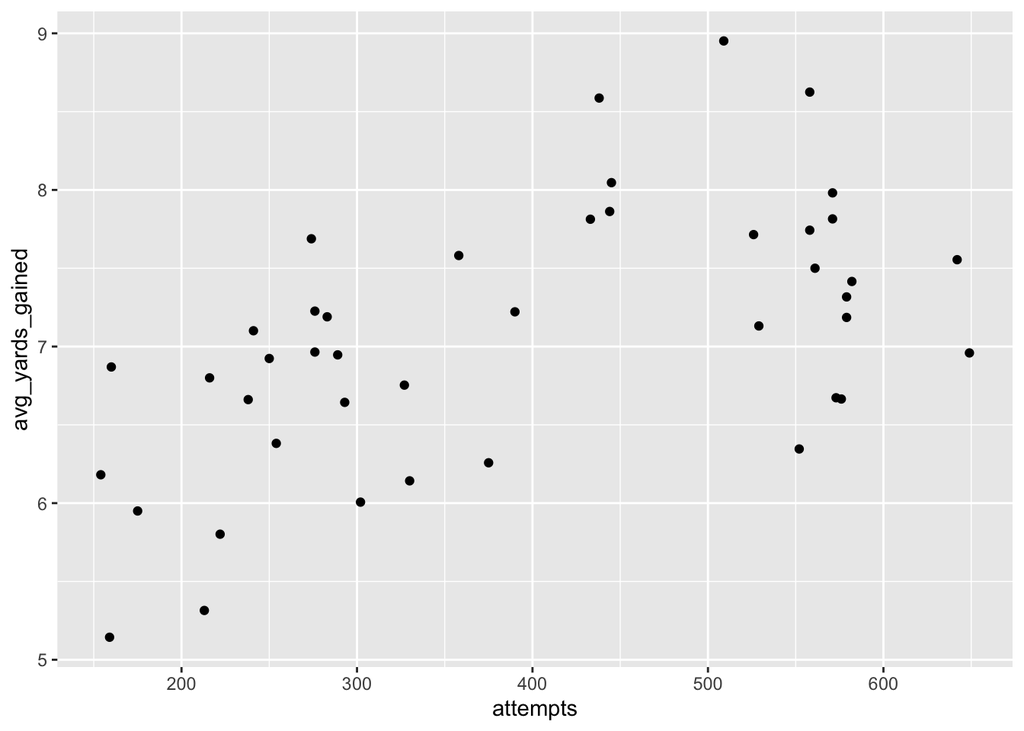

```r
ggplot(pbp_grouped, aes(x = attempts, y = avg_yards_gained)) +
  geom_point()
```

9. Next, add an abline to the plot using `geom_abline()` to see how linear the data may be. Use the `slope` and `intercept` arguments to set the slope to 0.005 and the intercept to 5. Set the linetype to dashed, and the color to black. This line was chosen by hand; in Lecture 6, you will learn how to fit regression models to the data mathematically to make a line of best fit.
10. Now, add a third variable. Set the color to equal `avg_cpoe` and use `scale_color_distiller()` to set the color scale.
11. Finally, visualize the quarterbacks with the highest `avg_yards_gained`. Use `arrange()` and `slice_head()` to obtain the top 10 quarterbacks, then generate a bar plot with `geom_col()`. Make sure to either use 45 degree axis labels or flip the coordinates with `coord_flip()` so that the QB names are visible.
12. Let’s do one more small case study on explosive plays. First, start by filtering the data as below to get the appropriate columns.

```r
pbp_explosive <- pbp_2024 %>%
  filter(play_type %in% c("pass", "run"),
         !is.na(yards_gained),
         !is.na(defteam),
         !is.na(down),
         !is.na(yardline_100)) %>%
  mutate(
    explosive = case_when(
      play_type == "run"  & yards_gained >= 10 ~ 1,
      play_type == "pass" & yards_gained >= 20 ~ 1,
      TRUE ~ 0
    )
  ) %>%
  filter(explosive == 1) %>%
  select(
    game_id,
    play_id,
    defteam,
    play_type,
    ydstogo,
    yardline_100,
    yards_gained,
    explosive
  )

head(pbp_explosive)
```

```
## ── nflverse play by play data ──────────────────────────────────────────────────
```

```
## ℹ Data updated: 2025-09-03 05:24:26 EDT
```

```
## # A tibble: 6 × 8
##   game_id  play_id defteam play_type ydstogo yardline_100 yards_gained explosive
##   <chr>      <dbl> <chr>   <chr>       <dbl>        <dbl>        <dbl>     <dbl>
## 1 2024_01…      83 BUF     pass            7           67           22         1
## 2 2024_01…     622 BUF     pass            4           65           24         1
## 3 2024_01…     707 BUF     run            10           28           11         1
## 4 2024_01…     902 ARI     run            10           64           15         1
## 5 2024_01…     946 ARI     pass            5           44           23         1
## 6 2024_01…    1269 BUF     run             6           56           12         1
```

13. Visualize the distribution of explosive plays by defensive team. Use `geom_bar()` to create a bar plot of the number of explosive plays by `defteam`.
14. Take a closer look at the worst defenses against explosive plays. Group by defensive team and play type, then use `reframe()` to obtain the number of explosive plays in each category. Use `arrange()` and `slice_head()` to obtain the top 10 teams within each play type. Replot the bar graphs and facet by pass or run plays.
15. Finally, visualize the relationship between explosive plays and yards to go with a heat map. First, run the following code below to obtain the needed columns for this plot.

```r
pbp_explosive_rate <- pbp_2024 %>%
  filter(play_type %in% c("pass", "run"),
         !is.na(yards_gained),
         !is.na(defteam),
         !is.na(down),
         !is.na(yardline_100)) %>%
  mutate(
    explosive = case_when(
      play_type == "run"  & yards_gained >= 10 ~ 1,
      play_type == "pass" & yards_gained >= 20 ~ 1,
      TRUE ~ 0
    )
  ) %>%
  select(
    game_id,
    play_id,
    defteam,
    play_type,
    ydstogo,
    yardline_100,
    yards_gained,
    explosive
  )
```

Then, group by `defteam` and `ydstogo` and obtain the explosive play *rate*, instead of number of explosive plays. Then use `geom_tile()` to create a heat map with `defteam` on the x-axis, `ydstogo` on the y-axis, and fill based on the explosive play rate.